# Simple Linear Regression

Marc Los Huertos

EA030 · Compiled 2026-04-14

EA030 — Basic Statistics — Module 07

# Simple Linear Regression

**Prof. Marc Los Huertos** • Pomona College

← Back to RTricks

Intuition The Model Fitting in R Reading Output Assumptions Diagnostics Inference Prediction

By the end of this module you will be able to

1. Fit a simple linear regression with `lm()` and read the summary output.
2. Interpret the intercept and slope in the units of your data.
3. Produce and diagnose residual plots for the four key assumptions.
4. Distinguish between confidence intervals for the mean and prediction intervals for new observations.
5. Report regression results following standard scientific conventions.

> **What this module covers.** Simple linear regression describes the straight-line relationship between one continuous predictor and one continuous outcome. This tutorial builds the model from first principles, shows you how to fit and interpret `lm()` output, diagnose assumption violations with residual plots, and draw valid inference from slope confidence intervals and F-tests.

## 1. The Intuition

Regression asks: **if I know x, what is my best guess for y?** The word *simple* means one predictor; *linear* means the relationship is a straight line.

Environmental applications are everywhere. Does PM2.5 increase as traffic volume rises? Does soil carbon decrease with distance from a riparian corridor? Does tree height predict biomass? In every case the method is the same: fit a line that minimizes prediction error, then ask how confident we are in its slope.

```r
# Ozone vs. solar radiation from the built-in airquality dataset
data(airquality)
aq <- na.omit(airquality[, c("Ozone", "Solar.R", "Temp", "Wind")])
head(aq)
```

```
##   Ozone Solar.R Temp Wind
## 1    41     190   67  7.4
## 2    36     118   72  8.0
## 3    12     149   74 12.6
## 4    18     313   62 11.5
## 7    23     299   65  8.6
## 8    19      99   59 13.8
```

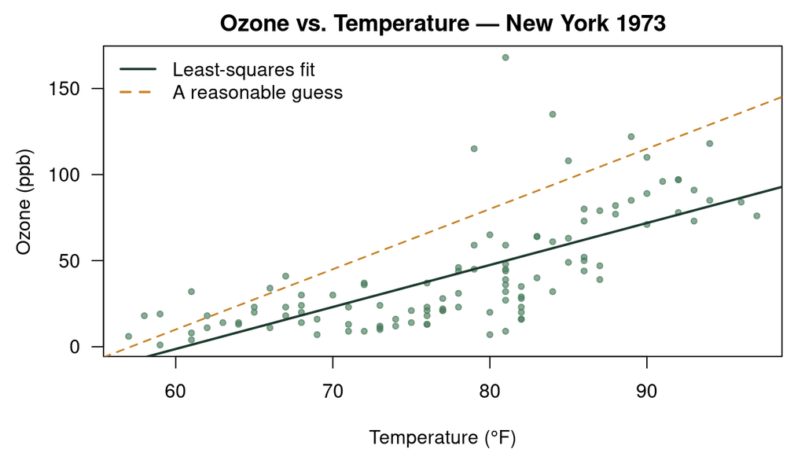

Ozone concentration vs. temperature in New York, summer 1973. Each point is one day. The dashed line is a visual guess; the solid line is the least-squares fit.

## 2. The Model

The simple linear regression model is:

$$y_i = \beta_0 + \beta_1 x_i +
\varepsilon_i$$

where:

- $y_i$ is the observed response for observation $i$
- $x_i$ is the predictor value
- $\beta_0$ is the **intercept** — the predicted value of y when x = 0
- $\beta_1$ is the **slope** — the change in y for a one-unit increase in x
- $\varepsilon_i \sim N(0, \sigma^2)$ is the **error** term — the part of y not explained by x

The **ordinary least-squares (OLS)** estimator chooses $\hat\beta_0$ and $\hat\beta_1$ to minimize the sum of squared residuals:

$$\text{SSR} = \sum_{i=1}^n (y_i - \hat
y_i)^2 \quad \text{where} \quad \hat y_i = \hat\beta_0 + \hat\beta_1
x_i$$

The closed-form solution is:

$$\hat\beta_1 = \frac{\sum(x_i - \bar
x)(y_i - \bar y)}{\sum(x_i - \bar x)^2} =
\frac{S_{xy}}{S_{xx}}$$

$$\hat\beta_0 = \bar y - \hat\beta_1 \bar
x$$

**Formula in words** The slope is the covariance of x and y divided by the variance of x. The intercept is chosen so the line passes through (x̄, ȳ).

### Compute by hand first

```r
x <- aq$Temp
y <- aq$Ozone

b1 <- sum((x - mean(x)) * (y - mean(y))) / sum((x - mean(x))^2)
b0 <- mean(y) - b1 * mean(x)

knitr::kable(
  data.frame(
    Coefficient = c("Slope (β₁)", "Intercept (β₀)"),
    Estimate    = round(c(b1, b0), 3),
    Interpretation = c("ppb per °F", "ppb when Temp = 0°F")
  ),
  caption = "OLS estimates computed by hand."
)
```

OLS estimates computed by hand.

| Coefficient | Estimate | Interpretation |
| --- | --- | --- |
| Slope (β₁) | 2.439 | ppb per °F |
| Intercept (β₀) | -147.646 | ppb when Temp = 0°F |

## 3. Fitting in R with `lm()`

In practice, always use `lm()`. The formula syntax `y ~ x` maps directly onto the statistical model $y = \beta_0 + \beta_1 x + \varepsilon$.

```r
mod <- lm(Ozone ~ Temp, data = aq)
```

The fitted object `mod` contains everything: coefficients, residuals, fitted values, the variance–covariance matrix of the estimates, and more.

```r
coef(mod)          # intercept and slope
```

```
## (Intercept)        Temp
##  -147.64607     2.43911
```

```r
fitted(mod)[1:6]   # predicted values yhat
```

```
##         1         2         3         4         7         8
## 15.774291 27.969841 32.848061  3.578742 10.896071 -3.738588
```

```r
residuals(mod)[1:6] # observed - predicted
```

```
##          1          2          3          4          7          8
##  25.225709   8.030159 -20.848061  14.421258  12.103929  22.738588
```

## 4. Reading `summary()` Output

```r
summary(mod)
```

```
##
## Call:
## lm(formula = Ozone ~ Temp, data = aq)
##
## Residuals:
##     Min      1Q  Median      3Q     Max
## -40.922 -17.459  -0.874  10.444 118.078
##
## Coefficients:
##              Estimate Std. Error t value Pr(>|t|)
## (Intercept) -147.6461    18.7553  -7.872 2.76e-12 ***
## Temp           2.4391     0.2393  10.192  < 2e-16 ***
## ---
## Signif. codes:  0 '***' 0.001 '**' 0.01 '*' 0.05 '.' 0.1 ' ' 1
##
## Residual standard error: 23.92 on 109 degrees of freedom
## Multiple R-squared:  0.488,  Adjusted R-squared:  0.4833
## F-statistic: 103.9 on 1 and 109 DF,  p-value: < 2.2e-16
```

**Residuals.** A five-number summary of the residuals. Ideally symmetric around zero. Large asymmetry suggests the normality assumption is violated.

**Coefficients table.** Each row is one model parameter.

| Column | Meaning |
| --- | --- |
| `Estimate` | $\hat\beta$ — the OLS coefficient |
| `Std. Error` | SE($\hat\beta$) — precision of the estimate |
| `t value` | $\hat\beta$ / SE — the test statistic for $H_0: \beta = 0$ |
| `Pr(>\|t\|)` | Two-tailed p-value for the t-test |

**Residual standard error (RSE).** $\hat\sigma$ — typical size of a residual. Smaller is better; units match y.

**R-squared.** The proportion of variance in y explained by x. $R^2 = 1 - \text{SS}_\text{res} / \text{SS}_\text{tot}$. Range 0–1; higher is better, but high $R^2$ does not guarantee the model is correct.

**F-statistic.** Tests whether the overall model explains more variance than a model with no predictors (intercept only). For simple regression, $F = t^2$.

**📌 The slope is the key result** In simple regression, the slope coefficient and its p-value are the primary result. A slope of 2.43 ppb/°F means: for each 1 °F rise in temperature, ozone increases by about 2.43 ppb on average. The p-value tests whether this relationship is distinguishable from zero given sampling variability.

## 5. The Four OLS Assumptions

Linear regression produces valid inference only when four assumptions hold. They are easiest to remember with the acronym **LINE**:

| Letter | Assumption | What “violation” looks like |
| --- | --- | --- |
| L | **L**inearity | Curved pattern in residuals vs. fitted |
| I | **I**ndependence | Residuals correlated over time or space |
| N | **N**ormality | Heavy-tailed or strongly skewed residuals |
| E | **E**qual variance (homoscedasticity) | Fan shape in residuals vs. fitted |

The most important are linearity and equal variance; the t-tests and confidence intervals are fairly robust to modest normality violations when n is large.

## 6. Residual Diagnostics

`plot(mod)` produces four standard diagnostic plots. Always examine all four.

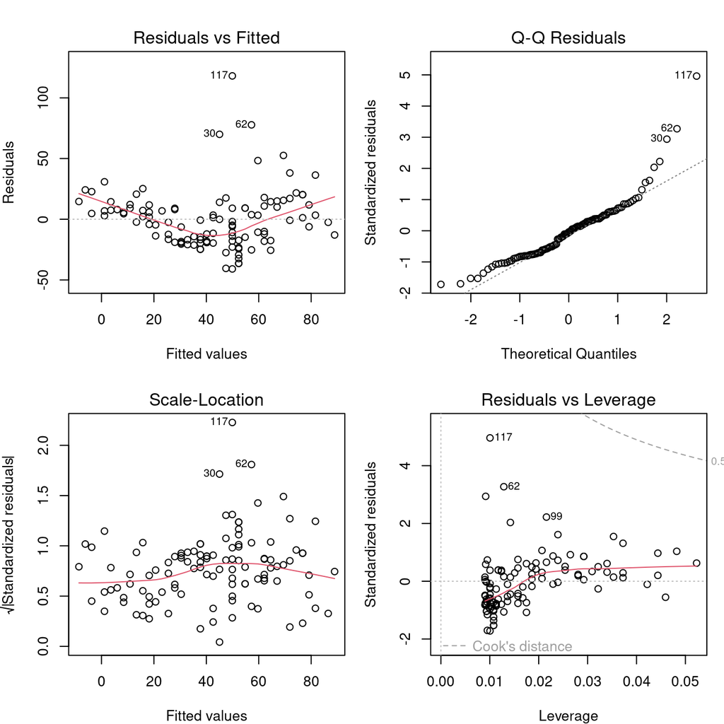

Four standard regression diagnostic plots for the ozone model. (1) Residuals vs. Fitted checks linearity and equal variance. (2) Q-Q plot checks normality. (3) Scale-Location is a second variance check. (4) Residuals vs. Leverage identifies influential points.

```r
par(mfrow = c(2, 2), mar = c(4, 4, 3, 1))
plot(mod)
```

```r
par(mfrow = c(1, 1))
```

### How to interpret each plot

**Residuals vs. Fitted (top-left).** Look for a horizontal band of points with no curve or funnel. A curved pattern indicates the relationship is not linear; a funnel indicates heteroscedasticity (unequal variance).

**Normal Q-Q (top-right).** Points should fall close to the diagonal line. Heavy tails (points curving upward at both ends) indicate the residuals are more extreme than a normal distribution predicts.

**Scale-Location (bottom-left).** The square root of the standardized residuals vs. fitted values. The fitted line should be roughly horizontal. An upward slope indicates that variance increases with the fitted value.

**Residuals vs. Leverage (bottom-right).** Identifies influential observations — points whose removal would substantially change the regression line. Points outside Cook’s distance contours (dashed lines) deserve scrutiny.

**⚠️ High leverage vs. high influence** A point has high **leverage** if its x-value is far from x̄ — it has the potential to pull the regression line. It has high **influence** if removing it actually changes the fit substantially. Both Cook’s distance and leverage are shown in plot 4.

### Checking for influential points

```r
# Cook's distance > 4/n is a common threshold
n  <- nrow(aq)
cd <- cooks.distance(mod)
influential <- which(cd > 4 / n)
```

5 observation(s) have Cook’s D > 4/n (row indices: 23, 34, 63, 77, 80).

```r
if (length(influential) > 0) {
  knitr::kable(
    aq[influential, ],
    caption = paste0("Observations with Cook's distance > 4/", n,
                     " (potentially influential).")
  )
}
```

Observations with Cook’s distance > 4/111 (potentially influential).

|  | Ozone | Solar.R | Temp | Wind |
| --- | --- | --- | --- | --- |
| 30 | 115 | 223 | 79 | 5.7 |
| 62 | 135 | 269 | 84 | 4.1 |
| 99 | 122 | 255 | 89 | 4.0 |
| 117 | 168 | 238 | 81 | 3.4 |
| 121 | 118 | 225 | 94 | 2.3 |

## 7. Inference: Confidence Intervals and the F-test

### Confidence interval for the slope

```r
confint(mod, level = 0.95)
```

```
##                   2.5 %      97.5 %
## (Intercept) -184.818372 -110.473773
## Temp           1.964787    2.913433
```

The 95% CI for the slope is more informative than the p-value alone: it shows the range of plausible values for the true population slope. A narrow CI indicates the estimate is precise; a wide CI indicates high uncertainty.

### Visualizing the fitted line with uncertainty band

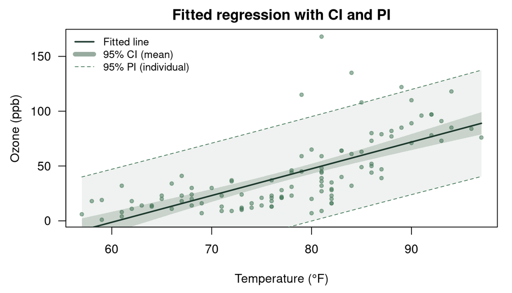

Fitted regression line (dark) with 95% confidence band (grey) and 95% prediction interval (dashed). The CI captures uncertainty in the mean response; the PI captures uncertainty in a single future observation.

```r
new_x  <- data.frame(Temp = seq(min(aq$Temp), max(aq$Temp), length.out = 200))
ci_fit <- predict(mod, newdata = new_x, interval = "confidence")
pi_fit <- predict(mod, newdata = new_x, interval = "prediction")

par(las = 1, mar = c(4.5, 4.5, 2, 1))
plot(Ozone ~ Temp, data = aq, pch = 20,
     col = rgb(0.29, 0.49, 0.37, 0.55),
     xlab = "Temperature (°F)", ylab = "Ozone (ppb)",
     main = "Fitted regression with CI and PI")

# Prediction interval ribbon
polygon(c(new_x$Temp, rev(new_x$Temp)),
        c(pi_fit[, "lwr"], rev(pi_fit[, "upr"])),
        col = rgb(0.2, 0.35, 0.25, 0.08), border = NA)

# Confidence interval ribbon
polygon(c(new_x$Temp, rev(new_x$Temp)),
        c(ci_fit[, "lwr"], rev(ci_fit[, "upr"])),
        col = rgb(0.2, 0.35, 0.25, 0.20), border = NA)

lines(new_x$Temp, ci_fit[, "fit"], col = "#1e3a2f", lwd = 2)
lines(new_x$Temp, pi_fit[, "lwr"], col = "#4a7c5e", lwd = 1, lty = 2)
lines(new_x$Temp, pi_fit[, "upr"], col = "#4a7c5e", lwd = 1, lty = 2)

legend("topleft",
       legend = c("Fitted line", "95% CI (mean)", "95% PI (individual)"),
       col = c("#1e3a2f", rgb(0.2,.35,.25,.5), "#4a7c5e"),
       lty = c(1, 1, 2), lwd = c(2, 6, 1), bty = "n", cex = 0.85)
```

**📌 CI vs. PI — a critical distinction** The **confidence interval** captures uncertainty about the mean response at a given x (the population average). The **prediction interval** captures uncertainty about a single new observation. The PI is always wider because it must account for both the uncertainty in the mean *and* the random scatter of individual observations around that mean.

## 8. Making Predictions

```r
# Predict ozone at specific temperatures
predict_data <- data.frame(Temp = c(65, 75, 85, 95))
preds <- predict(mod, newdata = predict_data, interval = "confidence")

result <- cbind(predict_data, round(preds, 1))
names(result) <- c("Temp (°F)", "Predicted Ozone (ppb)", "95% CI Lower", "95% CI Upper")
knitr::kable(result, caption = "Predicted mean ozone at selected temperatures.")
```

Predicted mean ozone at selected temperatures.

| Temp (°F) | Predicted Ozone (ppb) | 95% CI Lower | 95% CI Upper |
| --- | --- | --- | --- |
| 65 | 10.9 | 3.3 | 18.5 |
| 75 | 35.3 | 30.6 | 40.0 |
| 85 | 59.7 | 54.0 | 65.3 |
| 95 | 84.1 | 74.7 | 93.4 |

**⚠️ Do not extrapolate** Predictions are only reliable within the range of the observed x values. The model has no information about the relationship outside that range — and the relationship may be nonlinear beyond the observed data.

### The complete workflow in one block

```r
# 1. Explore
plot(y ~ x, data = mydata)

# 2. Fit
mod <- lm(y ~ x, data = mydata)

# 3. Summarize
summary(mod)
confint(mod)

# 4. Diagnose
par(mfrow = c(2, 2)); plot(mod); par(mfrow = c(1, 1))

# 5. Predict
predict(mod, newdata = data.frame(x = new_values), interval = "confidence")
```

#### 🔑 Key takeaways

- `lm(y ~ x)` fits the OLS line. The formula maps directly onto $y = \beta_0 + \beta_1 x + \varepsilon$.
- The **slope** is the primary result: it quantifies the change in y per unit change in x. Always report it with a confidence interval.
- **R²** measures fit, not causation. A high R² does not mean x causes y.
- Check the four **LINE assumptions** with `plot(mod)` before reporting results. Curved residuals invalidate the model; heteroscedasticity inflates standard errors.
- Use `predict()` with `interval = “confidence”` for the mean response and `interval = “prediction”` for individual observations.

### What’s next?

- **ANOVA** — compare means across three or more groups
- **Multiple Regression & GLMs** — add more predictors and handle count or binary outcomes

✏️ Practice Exercises

Exercise 1 — Fit and interpret

Using `airquality`, fit a linear model predicting `Ozone` from `Temp`. (a) Report the slope, its 95% CI, and the R². (b) Write one sentence interpreting the slope in plain language, including units. (c) Is the intercept scientifically meaningful here?

**Show solution**

```
mod <- lm(Ozone ~ Temp, data = airquality)
summary(mod)
confint(mod)
```

Exercise 2 — Residual diagnostics

Run `par(mfrow=c(2,2)); plot(mod)` on your model from Exercise 1. Identify (a) any evidence of non-linearity in the Residuals vs. Fitted plot, (b) any high-leverage points in the Scale–Location and Cook’s distance plots, and (c) whether residuals appear approximately normal in the Q–Q plot.

**Show solution**

```
par(mfrow = c(2,2))
plot(mod)
```

The Residuals vs. Fitted plot shows a slight curve — ozone–temperature may have a non-linear component. Observations 117 and 62 appear repeatedly as potential outliers/leverage points. The Q–Q plot shows right-skew, consistent with ozone’s skewed distribution. A log transformation of Ozone may help.

Hypothesis Testing ↑ Module Index ANOVA